# vecCalc version 3.0

Nick James

02/05/2018

# 1 Introduction

Having recovered from the outrageous success of simplePathWriter, which I’ve probably used about three times in the last five years, I grew frustrated with it’s limitations. Having tried and failed to do geometry with it I trawled around and found some remarkable software for doing the necessary. However these packages involved learning curves and some pretty idiosyncratic UI misfeatures. One, which really produces the goods, has a theorem prover attached, which is way over my pay grade.

So here we are: yet another not invented here lash up! This one is lightweight, unsuprising and programmer friendly. It produces `.svg` files of simple (no curves) geometrical figures from an equally simple text specification. This means the figures are easily and accurately editable and reproducible.

Enjoy!

# 2 Installation

Download the zip, extract to somewhere handy, use vecCalc.exe. c++ source code is included, it should compile on any respectable operating system.

# 3 Synopsis

```
vecCalc -h? -v? -d? -o? -svg? filename?
```

options are:

```
-d          : dump coordinates
-h          : this help
-o          : output filename
-svg        : (default)write svg paths and circles
-v          : version
```

The optional filename argument contains the specification for the figure.

# 4 Action

The intuition is that vecCalc is used in the same way you would go about setting a figure out. Define a couple of points, draw a line between them, bisect the line, draw a perpendicular and so on and so forth.

vecCalc reads the input, consisting of instructions to place points and lines in the plane, along with rendering directions for line style, visibility etc etc. the `svg` output is sent to stdout, or to a file.

Each point and line is given a name, which can be used to refer to it should you wish to, say, join two points by a line or define a point as the intersection of two lines.

`svg` files can be opened directly by most browsers as well as by [inkscape](http://www.inkscape.org/). They can be rasterized into `png` by doing something along the lines of

```
inkscape -y 255 --export-png=picture.png -d 300 picture.svg
```

## 4.1 Instructions

### 4.1.1 Comments

Text between (and including) `//` and the end of line are comments and are ignored.

### 4.1.2 Svg Directives

These are instructions to change the rendering of the figure rather than it’s structure. They take the form `#svg directive` where directive can be one of the following:

#### 4.1.2.1 Line Directives

- `draw`  
  opposite of nodraw: show following points and lines.
- `nodraw`  
  don’t actually show following points and lines. They do exist though and can be used to construct further points and lines, whether hidden or not.
- `solid`  
  draw solid lines. *This also sets `draw`.*
- `dashed`  
  draw dashed lines. *This also sets `draw`.*

#### 4.1.2.2 Colour Directives

Colour directives affect the colour of lines only. They aren’t revoked by the line directives, so you can have coloured dashed lines and so on. Colours are strictly limited!

- `colR` Red
- `colG` Green
- `colB` Blue
- `colC` Cyan
- `colM` Magenta
- `colY` Yellow
- `colK` blacK
- `colW` White

#### 4.1.2.3 Examples

```
#svg dashed
#svg colM
```

### 4.1.3 Points, Lines &c

This is what you’ve all been waiting for. If you want a point, you say `pt`: for a line, you say `line`.

`pointRef`, `lineRef` and `circleRef` are the names of previously defined points, names and circles.

#### 4.1.3.1 Variables

Variables can be declared like so:

```
var variableName 42.0
```

they can be referenced by name and used in place of x and y coordinates in point definitions.

#### 4.1.3.2 Points

The obvious way is to give (x,y) coordinates of the desired point. They can also be specifed as the intersection of two lines, the midpoint of two points, midpoint of a line or the circumcentre of a triangle.

Point definitions are:

- `pt` NAME INTEGER INTEGER

  a point at (x,y)
- `pt` NAME pointRef lineRef INTEGER

  a point INTEGER from pointRef along a line parallel to lineRef
- `pt` NAME `inter` lineRef lineRef

  a point at the intersection of lineRef and lineRef
- `pt` NAME `bis` pointRef pointRef

  a point bisecting the line between pointRef and pointRef
- `pt` NAME `bis` lineRef

  a point bisecting lineRef
- `pt` NAME pointRef `+` pointRef

  a point at pointRef `+` pointRef
- `pt` NAME pointRef `-` pointRef

  a point at pointRef `-` pointRef
- `pt` NAME pointRef `*` INTEGER

  a point at INTEGER times pointRef from the origin
- `pt` NAME pointRef `/` INTEGER

  a point at pointRef divided by INTEGER from the origin
- `pt` NAME pointRef pointRef pointRef

  a point at the circumcentre of pointRef pointRef pointRef
- `pt` NAME `inter` arcRef arcRef

  a point at the intersection of arcRef and arcRef

Examples

```
pt A 320 160
pt B 400 600
pt C 180 640
pt P bis BC
pt Q bis A B
pt I inter AC BD
pt circumcent A B B'
```

#### 4.1.3.3 Lines

The simplest way is to define a line from point to point. There are also ways of creating perpendiculars and parallels along with moves and extensions of existing lines.

Line definitions are:

- line name pointRef pointRef

  a line between pointRef and pointRef
- line name perp lineRef pointRef

  a line through pointRef perpendicular to lineRef
- line name para lineRef pointRef

  a line through pointRef parallel to lineRef
- line name ext lineRef INTEGER

  a line made by extending lineRef by INTEGER at each end
- line name SLIDE lineRef INTEGER

  a line made by moving lineRef by INTEGER. positive numbers move in positive x direction, vertical lines move up for positive integers

Examples

```
line AB A B
line BC B C
line leftPara para AC B
line leftSlide sli leftPara -100
line perpAC perp AC C
```

#### 4.1.3.4 Circles

Circles can be defined as (centre, radius), (centre, point) or as the circumcentre of a triangle:

- `circ` name pointRef pointRef pointRef

  a circle through pointRef pointRef pointRef
- `circ` name pointRef INTEGER

  a circle centre pointRef radius INTEGER
- `circ` name pointRef pointRef

  a circle centre pointRef passing through pointRef

Examples

```
circ circumc A B B'
circ c50 B' 50
circ c4 A B
```

#### 4.1.3.5 Arcs

Arcs can be defined as (centre, radius, point, point) or (centre, radius, angle, angle). The definition respects the from - to order the arc is specified in: unlike `ang` which always choses the non reflex arc.

- `arc` name pointRef INTEGER pointRef pointRef

  an arc centre pointRef, radius INTEGER sector defined by pointRef pointRef
- `arc` name pointRef INTEGER INTEGER INTEGER

  an arc centre pointRef, radius INTEGER sector defined by INTEGER INTEGER in *degrees*
- `arc` name pointRef pointRef INTEGER INTEGER

  an arc centre pointRef, passing through pointRef, sector defined by INTEGER INTEGER in *degrees*

Examples

```
arc arc2 75 D 315 0
arc arc1-internal 50 A D B
```

#### 4.1.3.6 Angles

Angles can be marked and labelled like so:

- `ang` name pointRef pointRef pointRef

  labels angle pointRef pointRef pointRef with name

Examples

```
ang ad A I D
ang cd C I D
```

#### 4.1.3.7 Identifiers

`pointRef`s and `lineRefs` can be made up of letters a-z, A-Z, hyphens, single and double quotes.

Examples

```
A
A'
A"
A_B
a-b
```

# 5 Dodges

If a line segment is on the right line, but in the wrong place, use something like

```
pt pointA
pt pointB
#svg nodraw
line wrongLine pointA pointB
#svg draw
line rightLine sli wrongLine 42
```

Forgetting to use `#svg nodraw ... #svg draw` can lead to confusion and dismay!

If a line segment isn’t quite reaching as far as you’d like then do something like

```
pt pointA
pt pointB
#svg nodraw
line wrongLine pointA pointB
#svg draw
line rightLine ext wrongLine 250
```

Identifiers - point and line names - are restricted to ascii characters. Should you need more expressive identifiers unicode escapes can be used, examples follow:

## 5.1 Greek Letters

| code | letter | code | letter |
| --- | --- | --- | --- |
| `&#913;` | Α | `&#945;` | α |
| `&#914;` | Β | `&#946;` | β |
| `&#915;` | Γ | `&#947;` | γ |
| `&#916;` | Δ | `&#948;` | δ |
| `&#917;` | Ε | `&#949;` | ε |
| `&#918;` | Ζ | `&#950;` | ζ |
| `&#919;` | Η | `&#951;` | η |
| `&#920;` | Θ | `&#952;` | θ |
| `&#921;` | Ι | `&#953;` | ι |
| `&#922;` | Κ | `&#954;` | κ |
| `&#923;` | Λ | `&#955;` | λ |
| `&#924;` | Μ | `&#956;` | μ |
| `&#925;` | Ν | `&#957;` | ν |
| `&#926;` | Ξ | `&#958;` | ξ |
| `&#927;` | Ο | `&#959;` | ο |
| `&#928;` | Π | `&#960;` | π |
| `&#929;` | Ρ | `&#961;` | ρ |
| `&#931;` | Σ | `&#963;` | σ |
| `&#932;` | Τ | `&#964;` | τ |
| `&#933;` | Υ | `&#965;` | υ |
| `&#934;` | Φ | `&#966;` | φ |
| `&#935;` | Χ | `&#967;` | χ |
| `&#936;` | Ψ | `&#968;` | ψ |
| `&#937;` | Ω | `&#969;` | ω |

## 5.2 Fractions

| code | fraction |
| --- | --- |
| `&#188;` | ¼ |
| `&#189;` | ½ |
| `&#190;` | ¾ |
| `&#8531;` | ⅓ |
| `&#8532;` | ⅔ |
| `&#8533;` | ⅕ |
| `&#8534;` | ⅖ |
| `&#8535;` | ⅗ |
| `&#8536;` | ⅘ |
| `&#8537;` | ⅙ |
| `&#8538;` | ⅚ |
| `&#8539;` | ⅛ |
| `&#8540;` | ⅜ |
| `&#8541;` | ⅝ |
| `&#8542;` | ⅞ |

# 6 Example

Given this input:

```
// quadrilateral
pt O 0 0

var Ay 160

pt A 320 Ay
pt B 400 600
pt C 180 640
pt D 115 360

#svg colK
line AB A B
line BC B C
line CD C D
line DA D A
#svg colB
line AC A C
line BD B D

#svg dashed
line leftPara para AC B
#svg nodraw
line rightPara para AC D
#svg dashed
line Dext sli rightPara -100

pt P bis BC
pt Q bis D C
pt R bis A C

#svg colM
#svg dashed
line BR B R
line AP A P
line DR D R
line AQ A Q

#svg dashed
pt I inter AC BD
pt X inter BR AP
pt Y inter DR AQ

line perpAC perp AC C

pt B' inter leftPara perpAC
pt D' inter rightPara perpAC

#svg solid
ang &#952; D I A
```

This command line…

```
vecCalc.exe -o example.svg example.vecCalc
```

…produces this figure.

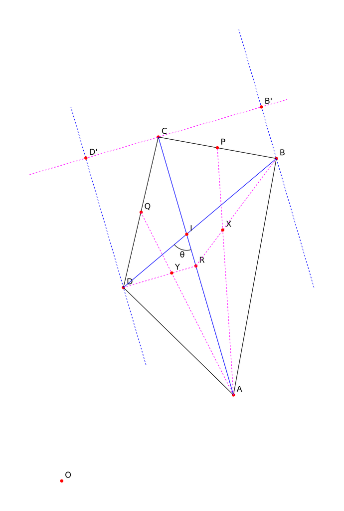

# 7 Programmer’s Notes

## 7.1 Programming model

The user supplies a specification of a drawing, in the form of object definitions, line definitions and rendering directives, one per line.

Objects must be defined before use. Points have their coordinates resolved on defintion and are entered into a points table. Lines are stored as references to their beginning and ending points. Circles and arcs are stored as centre, radius with optional arc start and end values.

The users specification is processed into a schedule. This schedule is executed by drawing the objects in the order specified, subject to the rendering directives. The rendering directives are put in the schedule as tokens which set flags used when executing the schedule. An include directive immediately inserts the file contents into the output.

## 7.2 Grammar

This is the grammar:

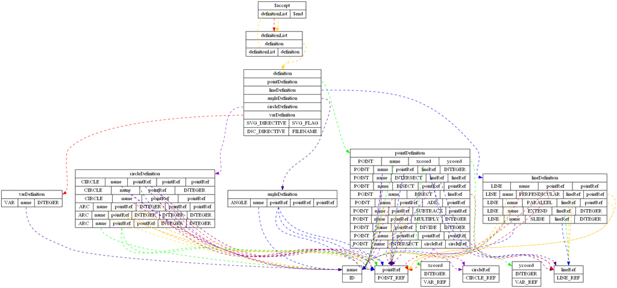

available in text form here

# 8 Bugs, Enhancements

## 8.1 Bugs

Undoubtedly.

Error reporting consists of the phrase “syntax error”. You may be given a line number.

## 8.2 Enhancements

# 9 Building

Use

```
source\compile.bat
```

in the distribution.

# 10 Colophon

Produced with:

```
pp vecCalc.txt | pandoc --self-contained --toc -N -c devDoc.css -s -t html5 -o vecCalc.html
```

2018-05-02 15:06:05